# Analysing Word Document frequency : Tf-Idf

Saumya Mehta

5/14/2018

## Term frequency in Jane Austen’s novel.

Finding the most common words in novels

```r
library(dplyr)
library(janeaustenr)
library(tidytext)
book_words <- austen_books() %>%
  unnest_tokens(word,text) %>%
  count(book, word, sort = T) %>%
  ungroup()

total_words <- book_words %>%
  group_by(book) %>%
  summarise(total =sum(n))


book_words <- left_join(book_words,total_words)
book_words
```

```
## # A tibble: 40,379 x 4
##    book              word      n  total
##    <fct>             <chr> <int>  <int>
##  1 Mansfield Park    the    6206 160460
##  2 Mansfield Park    to     5475 160460
##  3 Mansfield Park    and    5438 160460
##  4 Emma              to     5239 160996
##  5 Emma              the    5201 160996
##  6 Emma              and    4896 160996
##  7 Mansfield Park    of     4778 160460
##  8 Pride & Prejudice the    4331 122204
##  9 Emma              of     4291 160996
## 10 Pride & Prejudice to     4162 122204
## # ... with 40,369 more rows
```

n = number of times a word was used in the book. total = total number of words in the book.

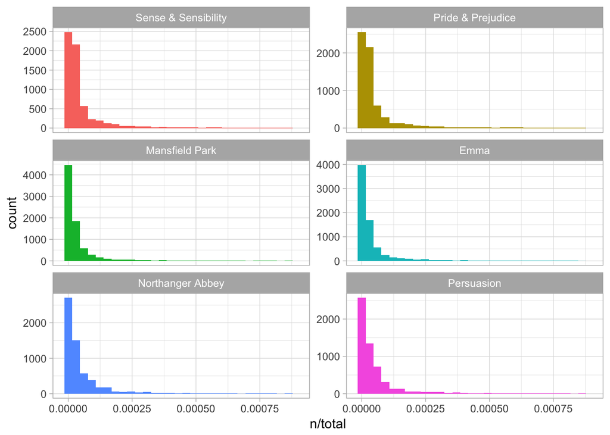

Figure 3.1: Term Frequency Distribution in Jane Austen’s Novels

## Zipf’s Law

Frequency of the word is inversely proportional to it’s rank.

```r
freq_by_rank <- book_words %>%
  group_by(book) %>%
  mutate(rank = row_number(),
          `term frequency` = n/total)
```

Zipf’s Law visualization

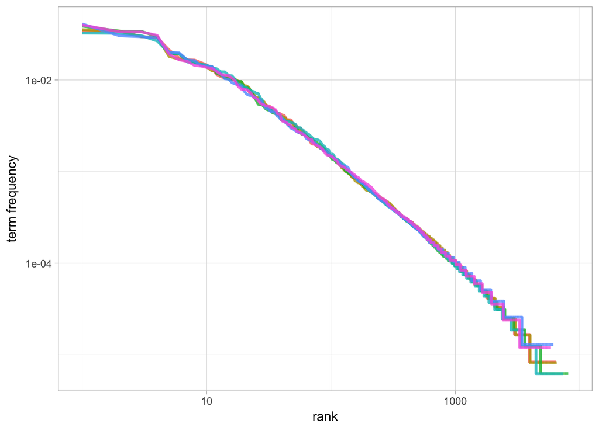

Figure 3.2: Zipf’s law for Jane Austen’s novels

## Bind tf-idf function

bind_tf_idf takes as input tidy dataset with one row per token per document form. One column contains the token and one column contains the document. For bind_tf_idf function, we only need all the terms in the document.

```r
book_words <- book_words %>%
  bind_tf_idf(word, book, n)
book_words
```

```
## # A tibble: 40,379 x 7
##    book              word      n  total     tf   idf tf_idf
##    <fct>             <chr> <int>  <int>  <dbl> <dbl>  <dbl>
##  1 Mansfield Park    the    6206 160460 0.0387    0.     0.
##  2 Mansfield Park    to     5475 160460 0.0341    0.     0.
##  3 Mansfield Park    and    5438 160460 0.0339    0.     0.
##  4 Emma              to     5239 160996 0.0325    0.     0.
##  5 Emma              the    5201 160996 0.0323    0.     0.
##  6 Emma              and    4896 160996 0.0304    0.     0.
##  7 Mansfield Park    of     4778 160460 0.0298    0.     0.
##  8 Pride & Prejudice the    4331 122204 0.0354    0.     0.
##  9 Emma              of     4291 160996 0.0267    0.     0.
## 10 Pride & Prejudice to     4162 122204 0.0341    0.     0.
## # ... with 40,369 more rows
```

idf and hence tf-idf is zero for most common words. idf is nearly zero for terms that occur in many documents in the collection.

```r
book_words %>%
  select(-total) %>%
  arrange(desc(tf-idf))
```

```
## # A tibble: 40,379 x 6
##    book                word      n     tf   idf tf_idf
##    <fct>               <chr> <int>  <dbl> <dbl>  <dbl>
##  1 Northanger Abbey    the    3179 0.0409    0.     0.
##  2 Persuasion          the    3329 0.0398    0.     0.
##  3 Mansfield Park      the    6206 0.0387    0.     0.
##  4 Pride & Prejudice   the    4331 0.0354    0.     0.
##  5 Sense & Sensibility to     4116 0.0343    0.     0.
##  6 Sense & Sensibility the    4105 0.0342    0.     0.
##  7 Mansfield Park      to     5475 0.0341    0.     0.
##  8 Pride & Prejudice   to     4162 0.0341    0.     0.
##  9 Mansfield Park      and    5438 0.0339    0.     0.
## 10 Persuasion          to     2808 0.0336    0.     0.
## # ... with 40,369 more rows
```

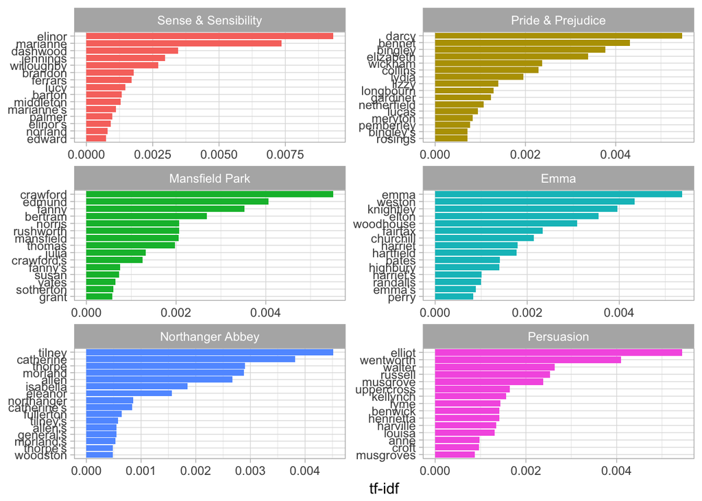

Figure 3.3: Highest tf-idf words in each of Jane Austen’s Novels

tf-idf indentifies the words that are important to a document in the collection of documents.

## Corpus of physical texts

```r
library(gutenbergr)
physics <- gutenberg_download(c(37729, 14725, 13746, 5001),
                              meta_fields = "author")
```

```
## Determining mirror for Project Gutenberg from http://www.gutenberg.org/robot/harvest
```

```
## Using mirror http://aleph.gutenberg.org
```

Now after extracting the texts, we need to unnest into tokens and count the occurence of each words.

```r
physics_words <- physics %>%
  unnest_tokens(word, text) %>%
  count(author, word, sort = TRUE) %>%
  ungroup()

physics_words
```

```
## # A tibble: 18,897 x 3
##    author                           word      n
##    <chr>                            <chr> <int>
##  1 Elliot, Robert H. (Robert Henry) the   13523
##  2 Elliot, Robert H. (Robert Henry) of     7867
##  3 Elliot, Robert H. (Robert Henry) and    5880
##  4 Elliot, Robert H. (Robert Henry) to     4977
##  5 Galilei, Galileo                 the    3760
##  6 Elliot, Robert H. (Robert Henry) a      3734
##  7 Elliot, Robert H. (Robert Henry) in     3693
##  8 Huygens, Christiaan              the    3553
##  9 Einstein, Albert                 the    2994
## 10 Elliot, Robert H. (Robert Henry) that   2635
## # ... with 18,887 more rows
```

Calculating tf-idf and visualizing high tf-idf words

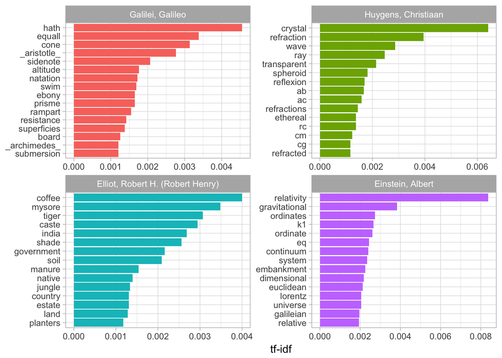

Figure 3.4: Highest tf-idf words in each physics texts

```r
library(stringr)
physics %>%
  filter(str_detect(text, "eq\\.")) %>%
  select(text)
```

```
## # A tibble: 55 x 1
##    text
##    <chr>
##  1 "                         eq. 1: file eq01.gif"
##  2 "                         eq. 2: file eq02.gif"
##  3 "                         eq. 3: file eq03.gif"
##  4 "                         eq. 4: file eq04.gif"
##  5 "                       eq. 05a: file eq05a.gif"
##  6 "                       eq. 05b: file eq05b.gif"
##  7 the distance between the points being eq. 06 .
##  8 direction of its length with a velocity v is eq. 06 of a metre.
##  9 velocity v=c we should have eq. 06a ,
## 10 the rod as judged from K1 would have been eq. 06 ;
## # ... with 45 more rows
```

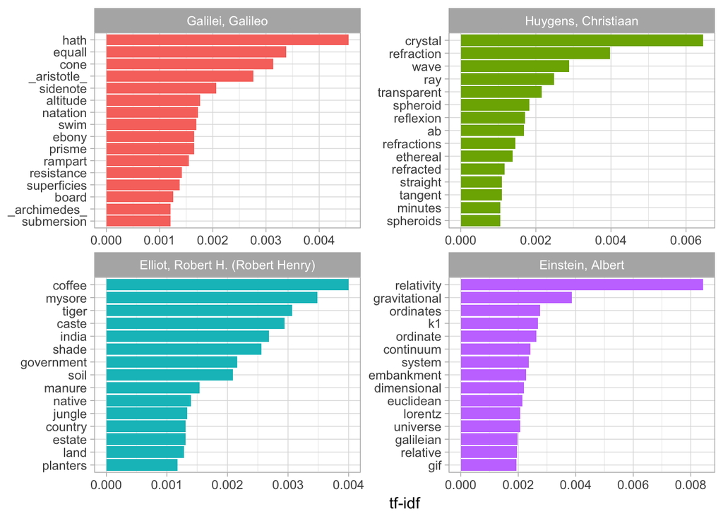

Figure 3.5: Highest tf-idf words in classic physics texts